# Matthew Bierman, Homework 6

## Problem 1: Default Data

### 1. Set Up Data

#### a.) Load the ISLR library and attach the Default data set

```r
library(ISLR)
data(Default)
attach(Default)
```

#### b.) Run the dim() and names() functions on Default

```r
dim(Default)
```

```
## [1] 10000     4
```

```r
names(Default)
```

```
## [1] "default" "student" "balance" "income"
```

#### c.) Use function set.seed(2017) so your results are reproducible

```r
set.seed(2017)
```

#### d.) Divide the data into 80% for training and the rest for a test set

```r
i <- sample(1:nrow(Default), nrow(Default) * 0.80, replace = FALSE)
train <- Default[i, ]
test <- Default[-i, ]
```

### 2. Logistic Regression Model

#### a.) Create a logistic regression model on the training data where default is predicted by all other variables

```r
glm <- glm(default~., data = train, family = binomial)
```

#### b.) Run a summary of the model

```r
summary(glm)
```

```
##
## Call:
## glm(formula = default ~ ., family = binomial, data = train)
##
## Deviance Residuals:
##     Min       1Q   Median       3Q      Max
## -2.4647  -0.1407  -0.0552  -0.0197   3.7584
##
## Coefficients:
##               Estimate Std. Error z value Pr(>|z|)
## (Intercept) -1.096e+01  5.553e-01 -19.736   <2e-16 ***
## studentYes  -5.435e-01  2.643e-01  -2.056   0.0397 *
## balance      5.774e-03  2.617e-04  22.062   <2e-16 ***
## income       2.838e-06  9.268e-06   0.306   0.7594
## ---
## Signif. codes:  0 '***' 0.001 '**' 0.01 '*' 0.05 '.' 0.1 ' ' 1
##
## (Dispersion parameter for binomial family taken to be 1)
##
##     Null deviance: 2340.6  on 7999  degrees of freedom
## Residual deviance: 1256.4  on 7996  degrees of freedom
## AIC: 1264.4
##
## Number of Fisher Scoring iterations: 8
```

#### c.) Predict Yes/No on the test data

```r
probs <- predict(glm, newdata = test, type = "response")
pred <- ifelse(probs > 0.5, "Yes", "No")
```

#### d.) Compute the accuracy

```r
table(pred, test$default)
```

```
##
## pred    No  Yes
##   No  1923   47
##   Yes   11   19
```

```r
mean(pred == test$default)
```

```
## [1] 0.971
```

### 3. Decision Tree Model

#### a.) Create a decision tree model on the training data

```r
library(tree)
tree <- tree(default~., data = train)
```

#### b.) Run a summary of the model

```r
summary(tree)
```

```
##
## Classification tree:
## tree(formula = default ~ ., data = train)
## Variables actually used in tree construction:
## [1] "balance"
## Number of terminal nodes:  5
## Residual mean deviance:  0.1592 = 1273 / 7995
## Misclassification error rate: 0.02638 = 211 / 8000
```

#### c.) Make predictions for the test set

```r
pred <- predict(tree, newdata = test, type = "class")
```

#### d.) Compute the accuracy

```r
table(pred, test$default)
```

```
##
## pred    No  Yes
##   No  1920   44
##   Yes   14   22
```

```r
mean(pred == test$default)
```

```
## [1] 0.971
```

### 4. Display the Decision Tree

#### a.) Print the tree with labels

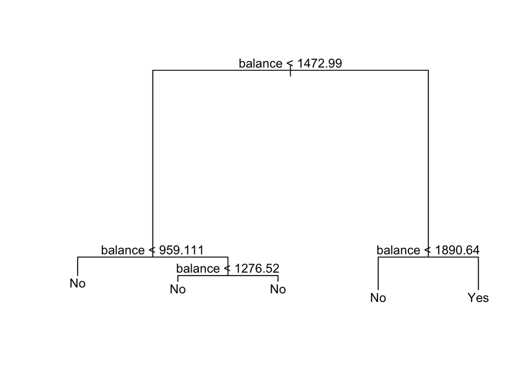

```r
plot(tree)
text(tree, pretty = 0)
```

#### b.) Display the tree in nested decision form by just using the tree name

```r
tree
```

```
## node), split, n, deviance, yval, (yprob)
##       * denotes terminal node
##
##  1) root 8000 2341.00 No ( 0.9666250 0.0333750 )
##    2) balance < 1472.99 7190  576.60 No ( 0.9933241 0.0066759 )
##      4) balance < 959.111 4835   50.31 No ( 0.9993795 0.0006205 ) *
##      5) balance > 959.111 2355  445.30 No ( 0.9808917 0.0191083 )
##       10) balance < 1276.52 1683  180.80 No ( 0.9904932 0.0095068 ) *
##       11) balance > 1276.52 672  239.00 No ( 0.9568452 0.0431548 ) *
##    3) balance > 1472.99 810  945.50 No ( 0.7296296 0.2703704 )
##      6) balance < 1890.64 666  625.20 No ( 0.8213213 0.1786787 ) *
##      7) balance > 1890.64 144  177.30 Yes ( 0.3055556 0.6944444 ) *
```

## Problem 2: Heart Data

### 1. Set Up Data

#### a.) Download the heart data to your machine from Piazza

N/A

#### b.) Load the data into R and attach it

```r
Heart <- read.csv(file = "/Users/biermanm/Documents/UT Dallas/Spring 2018/CS 4375.501/Heart.csv", header = TRUE, sep = ",")
attach(Heart)
```

#### c.) Remove the “X” column

```r
Heart <- Heart[, -1]
head(Heart)
```

```
##   Age Sex    ChestPain RestBP Chol Fbs RestECG MaxHR ExAng Oldpeak Slope
## 1  63   1      typical    145  233   1       2   150     0     2.3     3
## 2  67   1 asymptomatic    160  286   0       2   108     1     1.5     2
## 3  67   1 asymptomatic    120  229   0       2   129     1     2.6     2
## 4  37   1   nonanginal    130  250   0       0   187     0     3.5     3
## 5  41   0   nontypical    130  204   0       2   172     0     1.4     1
## 6  56   1   nontypical    120  236   0       0   178     0     0.8     1
##   Ca       Thal AHD
## 1  0      fixed  No
## 2  3     normal Yes
## 3  2 reversable Yes
## 4  0     normal  No
## 5  0     normal  No
## 6  0     normal  No
```

```r
i <- sample(1:nrow(Heart), nrow(Heart) * 0.80, replace = FALSE)
train <- Heart[i, ]
test <- Heart[-i, ]
```

### 2. Logistic Regression Model

#### a.) Create a logistic regression model on the training data where AHD is predicted by all other variables

```r
glm <- glm(AHD~., data = train, family = binomial)
```

#### b.) Run a summary of the model

```r
summary(glm)
```

```
##
## Call:
## glm(formula = AHD ~ ., family = binomial, data = train)
##
## Deviance Residuals:
##     Min       1Q   Median       3Q      Max
## -2.8053  -0.5175  -0.1148   0.3482   2.6301
##
## Coefficients:
##                       Estimate Std. Error z value Pr(>|z|)
## (Intercept)         -6.2829899  3.3766716  -1.861 0.062786 .
## Age                 -0.0008076  0.0281158  -0.029 0.977086
## Sex                  1.6366886  0.6176004   2.650 0.008047 **
## ChestPainnonanginal -1.8261883  0.5920501  -3.085 0.002039 **
## ChestPainnontypical -1.3951084  0.6624398  -2.106 0.035203 *
## ChestPaintypical    -2.0654097  0.8120834  -2.543 0.010980 *
## RestBP               0.0247602  0.0122801   2.016 0.043770 *
## Chol                 0.0073472  0.0042742   1.719 0.085620 .
## Fbs                 -0.7379998  0.7162537  -1.030 0.302841
## RestECG              0.0413706  0.2167910   0.191 0.848657
## MaxHR               -0.0169129  0.0133423  -1.268 0.204937
## ExAng                0.5760369  0.5045838   1.142 0.253617
## Oldpeak              0.4294572  0.2661749   1.613 0.106649
## Slope                0.8914615  0.4434027   2.011 0.044378 *
## Ca                   1.3369157  0.3520945   3.797 0.000146 ***
## Thalnormal           0.3034799  0.8383793   0.362 0.717364
## Thalreversable       1.4242169  0.8144006   1.749 0.080327 .
## ---
## Signif. codes:  0 '***' 0.001 '**' 0.01 '*' 0.05 '.' 0.1 ' ' 1
##
## (Dispersion parameter for binomial family taken to be 1)
##
##     Null deviance: 326.56  on 235  degrees of freedom
## Residual deviance: 150.89  on 219  degrees of freedom
##   (6 observations deleted due to missingness)
## AIC: 184.89
##
## Number of Fisher Scoring iterations: 6
```

#### c.) Predict Yes/No on the test data

```r
probs <- predict(glm, newdata = test, type = "response")
pred <- ifelse(probs > 0.5, "Yes", "No")
```

#### d.) Compute the accuracy

```r
table(pred, test$AHD)
```

```
##
## pred  No Yes
##   No  31   5
##   Yes  5  20
```

```r
mean(pred == test$AHD)
```

```
## [1] 0.8360656
```

### 3. Decision Tree Model

#### a.) Create a decision tree model on the training data

```r
library(tree)
tree <- tree(AHD~., data = train)
```

#### b.) Run a summary of the model

```r
summary(tree)
```

```
##
## Classification tree:
## tree(formula = AHD ~ ., data = train)
## Variables actually used in tree construction:
## [1] "Thal"      "ChestPain" "Oldpeak"   "Chol"      "Ca"        "Age"
## [7] "RestBP"    "MaxHR"     "RestECG"
## Number of terminal nodes:  18
## Residual mean deviance:  0.4739 = 103.3 / 218
## Misclassification error rate: 0.1144 = 27 / 236
```

#### c.) Make predictions for the test set

```r
pred <- predict(tree, newdata = test, type = "class")
```

#### d.) Compute the accuracy

```r
table(pred, test$AHD)
```

```
##
## pred  No Yes
##   No  26   8
##   Yes 10  17
```

```r
mean(pred == test$AHD)
```

```
## [1] 0.704918
```

### 4. Display the Decision Tree

#### a.) Print the tree with labels

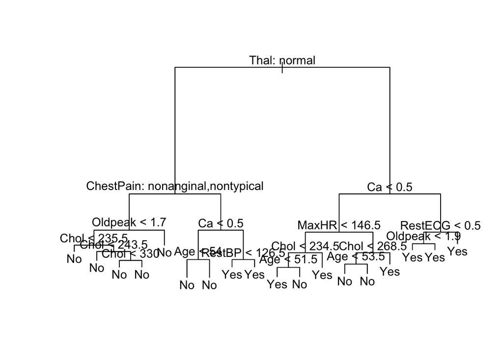

```r
plot(tree)
text(tree, pretty = 0)
```

#### b.) Display the tree in nested decision form by just using the tree name

```r
tree
```

```
## node), split, n, deviance, yval, (yprob)
##       * denotes terminal node
##
##  1) root 236 326.600 No ( 0.52542 0.47458 )
##    2) Thal: normal 125 130.400 No ( 0.78400 0.21600 )
##      4) ChestPain: nonanginal,nontypical 76  41.980 No ( 0.92105 0.07895 )
##        8) Oldpeak < 1.7 70  24.770 No ( 0.95714 0.04286 )
##         16) Chol < 235.5 32   0.000 No ( 1.00000 0.00000 ) *
##         17) Chol > 235.5 38  20.990 No ( 0.92105 0.07895 )
##           34) Chol < 243.5 5   6.730 No ( 0.60000 0.40000 ) *
##           35) Chol > 243.5 33   8.962 No ( 0.96970 0.03030 )
##             70) Chol < 330 28   0.000 No ( 1.00000 0.00000 ) *
##             71) Chol > 330 5   5.004 No ( 0.80000 0.20000 ) *
##        9) Oldpeak > 1.7 6   8.318 No ( 0.50000 0.50000 ) *
##      5) ChestPain: asymptomatic,typical 49  66.920 No ( 0.57143 0.42857 )
##       10) Ca < 0.5 32  33.620 No ( 0.78125 0.21875 )
##         20) Age < 54 15   0.000 No ( 1.00000 0.00000 ) *
##         21) Age > 54 17  23.030 No ( 0.58824 0.41176 ) *
##       11) Ca > 0.5 17  15.840 Yes ( 0.17647 0.82353 )
##         22) RestBP < 126.5 8   0.000 Yes ( 0.00000 1.00000 ) *
##         23) RestBP > 126.5 9  11.460 Yes ( 0.33333 0.66667 ) *
##    3) Thal: fixed,reversable 111 120.800 Yes ( 0.23423 0.76577 )
##      6) Ca < 0.5 50  68.590 Yes ( 0.44000 0.56000 )
##       12) MaxHR < 146.5 25  25.020 Yes ( 0.20000 0.80000 )
##         24) Chol < 234.5 12  16.300 Yes ( 0.41667 0.58333 )
##           48) Age < 51.5 7   5.742 Yes ( 0.14286 0.85714 ) *
##           49) Age > 51.5 5   5.004 No ( 0.80000 0.20000 ) *
##         25) Chol > 234.5 13   0.000 Yes ( 0.00000 1.00000 ) *
##       13) MaxHR > 146.5 25  31.340 No ( 0.68000 0.32000 )
##         26) Chol < 268.5 18  16.220 No ( 0.83333 0.16667 )
##           52) Age < 53.5 8  10.590 No ( 0.62500 0.37500 ) *
##           53) Age > 53.5 10   0.000 No ( 1.00000 0.00000 ) *
##         27) Chol > 268.5 7   8.376 Yes ( 0.28571 0.71429 ) *
##      7) Ca > 0.5 61  29.530 Yes ( 0.06557 0.93443 )
##       14) RestECG < 0.5 27  22.650 Yes ( 0.14815 0.85185 )
##         28) Oldpeak < 1.9 18  19.070 Yes ( 0.22222 0.77778 ) *
##         29) Oldpeak > 1.9 9   0.000 Yes ( 0.00000 1.00000 ) *
##       15) RestECG > 0.5 34   0.000 Yes ( 0.00000 1.00000 ) *
```